# Case Study 4

```r
library(s20x)
data(house.df)
head(house.df)
```

|  | advertised.price | sell.price |
| --- | --- | --- |
| 1 | 104000 | 90000 |
| 2 | 196000 | 183000 |
| 3 | 201000 | 173500 |
| 4 | 301000 | 262500 |
| 5 | 277000 | 241500 |
| 6 | 316000 | 275500 |

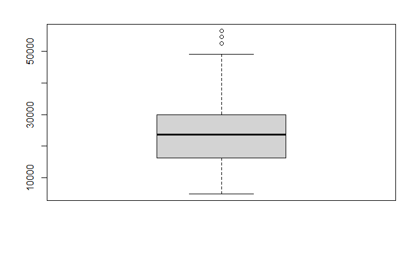

```r
summaryStats(priceDiff)
```

```
Minimum value:           5000
Maximum value:           56500
Mean value:              24310
Median:                  23750
Upper quartile:          30000
Lower quartile:          16375
Variance:                119130202.02
Standard deviation:      10914.68
Midspread (IQR):         13625
Skewness:                0.71
Number of data values:   100
```

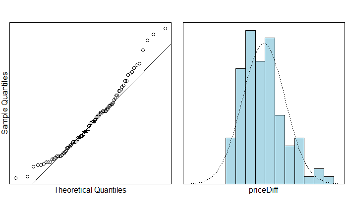

```r
t.test(priceDiff)
```

```
    One Sample t-test

data:  priceDiff
t = 22.273, df = 99, p-value < 2.2e-16
alternative hypothesis: true mean is not equal to 0
95 percent confidence interval:
 22144.29 26475.71
sample estimates:
mean of x
    24310
```

**Methods and Assumptions**

The data is paired, so we use a paired t-test.

The data is assumed to be independent. The points on the Q-Q plot seems to be right-skewed slightly. However, we can use Central Limit Theorem to assume that the data follows normality.

The data is modeled as diffPricei = mu + ei where diffPricei is the difference in the advertised and the actual house price, mu is the mean difference and ei ~iidN(0, sd^2).

**Executive Summary**

We were interested in finding out if there was a difference in the advertised price and the selling price for houses in Mt Eden. The data contained 100 random houses.

Since our original data involved two measurement on each house (the advertised price and the selling price), the difference between the two prices for each house has been analysed.

On average, the advertising price was found to be between 22140 NZD and 26475 NZD more than the selling price.

We concluded that there is a significant difference between the mean sale price and the mean advertised price for houses sold in Mt Eden.